# Final Project

Kaz Sakamoto

The goal of the final project is to systematically work through an analytics problem using MODA’s Open Source Analytics framework. Like MODA this class believes in many of the same values with analytics and public service. [link](https://moda-nyc.github.io/Project-Library//analytics/)

- **Transparency and Accountability:** We believe an open source model is more effective than a specific regulatory regime in enforcing the ethical development of algorithms in the public sector.
- **Enabling Replication:** Publishing source code allows agency clients to follow our steps to verify our conclusions. It also allows other agencies or jurisdictions to configure our work for their own context.
- **Continuous Improvement:** Open-sourcing analytics projects allows MODA’s data scientists to collaborate directly with analysts in adjacent roles across City government, who can improve on the models MODA develops.
- **Better Knowledge Management:** The best way to maintain and grow institutional knowledge is by making it discoverable through a Google search. Proactively publishing enforces both quality checks and makes information discoverable across the City.

As far as the expectation for the final project, this class will focus on the four sections of the process map which are:

1. Scoping
2. Data
3. Analysis
4. Handoff

Each section will be an assignment that will be completed and turned in before the final handoff.

## Scoping

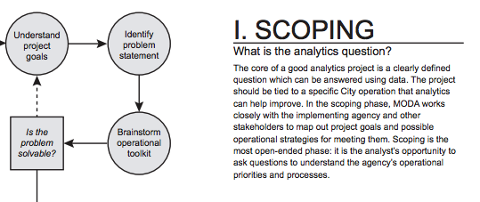

Select a [NYC agency](https://www1.nyc.gov/nyc-resources/agencies.page) as a client and do some research on what kind of problems they might need solving. Select three problems that the agency faces and do some research into what has been done to mitigate these issues. For each problem, surmise if these problems are a machine learning solvable task, also is this really going to solve the problem. You must have at least one ML solvable problem.

## Data

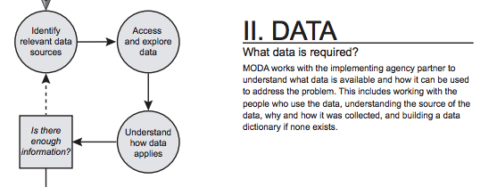

Without data a project cannot take off. What kind of data is required to solve the issue? Gather the data sources and describe the data and create a [data model](https://en.wikipedia.org/wiki/Data_model) (both conceptual and logical). A diagram should be attached.

## Analysis

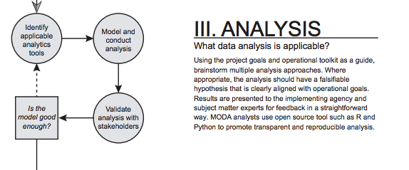

This is where the skills you learned in class will be primarily used. First identify what kind of tools and the approach that needs to be taken. You will then model and validate your results, by using different methods, add different types of data to get a better understanding of the problem. This should all be kept either in an .r file or .rmarkdown.

## Handoff

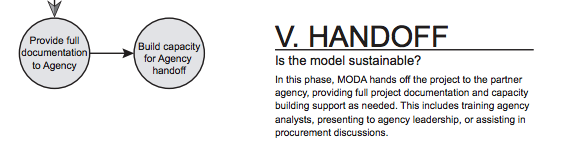

Finally all of the work needs to be packaged up as a report with documentation and assets.

## Examples

- **NYPD** Predicting the location of future parking tickets.
- **DOHMH** Classifying restaurant grades by new groupings on violations.
- **DSNY** Forecast on-street trash pickups.
- **MODA** Cooling towers and Legionnaires Disease [link](https://moda-nyc.github.io/Project-Library/projects/cooling-towers/)